# Discrete and Continuous Probability Distributions

X610 · Session 3 · Supplemental

## Today

- Discrete distributions: Bernoulli, Binomial, Geometric, and Poisson
- Continuous distributions: Uniform, Exponential, and Normal
- Parameters, support, tail behavior, transformations, and simulation
- Chi-squared, *t*, and *F* distributions and their roles in statistical inference

Reading: *Bernoulli’s Fallacy* Ch. 3

# Common discrete distributions

## Common discrete distributions: topics

- The standard discrete families: Bernoulli, geometric, binomial, negative binomial, Poisson
  - Each family combines a story and a PMF
- The Poisson as a limit of the binomial

Reading: *Bernoulli’s Fallacy* Ch. 3 (Quetelet)

## Bernoulli

**Bernoulli distribution**

If $X \sim \operatorname{Bernoulli}(p)$, where $0 \leq p \leq 1$, then
$$\Pr[X = x] = p^x (1-p)^{1-x}, \qquad x \in \{0, 1\}.$$

- One trial, binary outcome; $X = 1$ = “success”
  - Obviously a valid PMF: $(1 - p) + p = 1$
- This is the biased coin example from Session 1 (Example 1.2.7), now with a fancy name

## Random variables in python

Create random variables using `scipy.stats`. For example, create Bernoulli r.v. with $p = 0.3$:

```python
X = stats.bernoulli(0.3)
```

Consider two calculations:

```python
X.mean(), X.var()
```

```
(0.3, 0.21)
```

```python
samples = X.rvs(size=1000)
samples.mean(), samples.var()
```

```
(0.289, 0.20547900000000008)
```

Can also do things like:

```python
X.expect(lambda x: x**2) - X.expect(lambda x: x)**2
```

```
0.21
```

## Geometric

- Story: independent trials; $X$ counts trials until the first success

**Geometric distribution**

If $X \sim \operatorname{Geometric}(p)$, where $0 < p \leq 1$, then
$$\Pr[X = x] = p(1-p)^{x-1}, \qquad x \in \{1, 2, \ldots\}.$$

- First $(x - 1)$ trials fail, then success on trial $x$
  - read the PMF right from the story
- Countably infinite support

## Is the geometric PMF valid?

The probabilities must sum to one.

$$\sum_{k=1}^{\infty} \Pr[X = k] = \sum_{k=1}^{\infty} (1-p)^{k-1} p = p \sum_{j=0}^{\infty} r^j,$$
where $r = 1 - p$ and $j = k - 1$. Since $|r| < 1$, the geometric series formula gives

$$\sum_{j=0}^{\infty} r^j = \frac{1}{1-r} = \frac{1}{p}.$$
Therefore, $\sum_{k=1}^{\infty} \Pr[X = k] = p \cdot \frac{1}{p} = 1$.

## Simulating `waits`

For $p=0.3$, each random number below $0.3$ represents a success. Consider three simulated sequences (rows) of four trials (columns):

```python
p = 0.3
draws = np.array([[0.72, 0.11, 0.64, 0.08],
                  [0.94, 0.81, 0.46, 0.27],
                  [0.13, 0.71, 0.42, 0.88]])
waits = draws < p
waits, waits.argmax(axis=1) + 1
```

```
(array([[False,  True, False,  True],
        [False, False, False,  True],
        [ True, False, False, False]]),
 array([2, 4, 1]))
```

- `argmax(axis=1)` finds the first `True` in each row, using a zero-based index. Adding 1 converts it to the trial count: waits of 2, 4, and 1.
- The simulation applies the same operation to 100,000 rows of random draws.

**Note**

The simulation below checks only the first 16 trials. If all 16 fail, `argmax` returns 0 and incorrectly records a wait of 1. This happens with probability $0.7^{16}\approx0.0033$ per row.

## Geometric, simulated

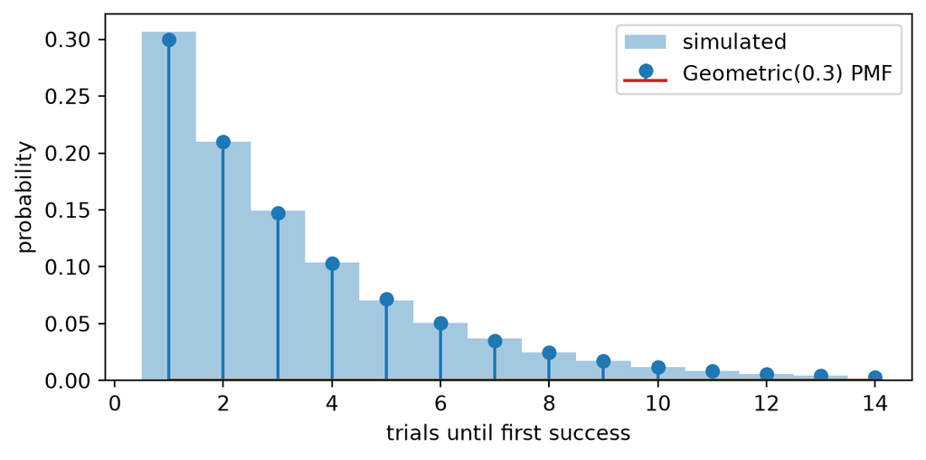

```python
p = 0.3; n = 100_000
waits = np.argmax(rng.random((n, 16)) < p, axis=1) + 1
x = np.arange(1, 15)
fig, ax = plt.subplots(figsize=(7, 3.2))
ax.hist(waits, bins=x - 0.5, density=True, alpha=0.4, label='simulated')
ax.stem(x, stats.geom(p).pmf(x), label=f'Geometric({p}) PMF')
ax.set(xlabel='trials until first success', ylabel='probability')
ax.legend()
plt.show()
```

## Geometric moments

Let $q=1-p$. Since $\sum_{k=1}^{\infty} kq^{k-1}=1/(1-q)^2$,

$$\begin{aligned}
\E[X]
&=p\sum_{k=1}^{\infty} kq^{k-1}
=\frac{p}{(1-q)^2}
=\frac{1}{p},\\[4pt]
\end{aligned}$$

Similarly can show $\V(X) = (1-p)/p^2$.

## Binomial

- Story: number of successes in $n$ independent Bernoulli trials

**Binomial distribution**

If $X \sim \operatorname{Bin}(n, p)$, where $n$ is a positive integer and $0 \leq p \leq 1$, then
$$\Pr[X = x] = \binom{n}{x} p^x (1-p)^{n-x}, \qquad x \in \{0, 1, \ldots, n\}.$$

- $\binom{n}{x}$ counts the ways to choose $x$ successes from $n$ trials
- Validity: use the Binomial Theorem with $a = p$, $b = 1 - p$

## Binomial, simulated

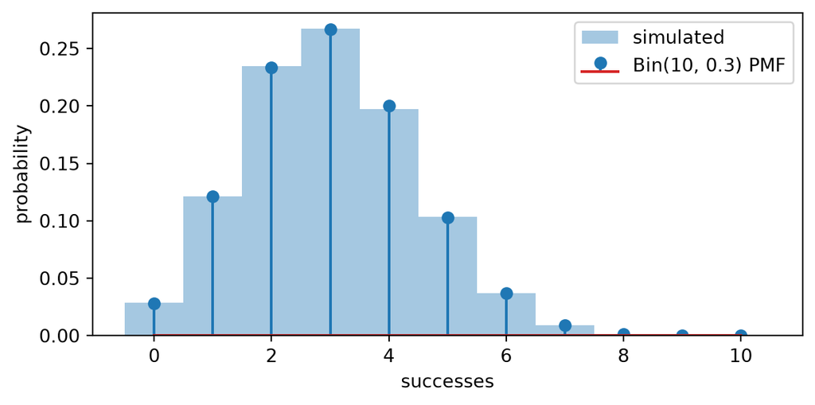

```python
n, p = 10, 0.3
draws = (rng.random((100_000, n)) < p).sum(axis=1)

x = np.arange(n + 1)
fig, ax = plt.subplots(figsize=(7, 3.2))
ax.hist(draws, bins=np.arange(n + 2) - 0.5, density=True, alpha=0.4,
        label='simulated')
ax.stem(x, stats.binom(n, p).pmf(x), label='Bin(10, 0.3) PMF')
ax.set(xlabel='successes', ylabel='probability')
ax.legend()
plt.show()
```

## Binomial moments

Write $X$ as the sum of $n$ success indicators, each with expectation $p$:

$$X = \sum_{i=1}^n I_i
\quad\Longrightarrow\quad
\E[X] = \sum_{i=1}^n \E[I_i] = np.$$

The algebra for the variance is a bit more involved, but the result is
$$\V(X) = np(1-p).$$

## A limit of the binomial

Fix the *expected count* $np = 5$ and let $n \to \infty$:

$$\operatorname{Bin}\left(10, \tfrac{1}{2}\right),\;
\operatorname{Bin}\left(100, \tfrac{1}{20}\right),\;
\operatorname{Bin}\left(1000, \tfrac{1}{200}\right),\; \ldots$$

**What happens to the PMF?**

- Does it flatten out, blow up, or settle down to something?
- Many trials, each with tiny success probability — what real-world settings fit that description?

## The Poisson limit

**Poisson distribution**

If $X \sim \operatorname{Poisson}(\lambda)$, where $\lambda > 0$, then
$$\Pr[X = x] = \frac{e^{-\lambda} \lambda^x}{x!}, \qquad x \in \{0, 1, 2, \ldots\}.$$

With $p_n = \lambda / n$:

$$\lim_{n \to \infty} \binom{n}{x} p_n^x (1 - p_n)^{n-x}
= \frac{e^{-\lambda} \lambda^x}{x!}.$$

- Counts of rare events in a fixed interval of time or space
- Validity: factor out $e^{-\lambda}$ and use the fact that $\sum_k \lambda^k / k! = e^{\lambda}$

## Poisson and horse kicks

[figure not shown]

## The Poisson limit

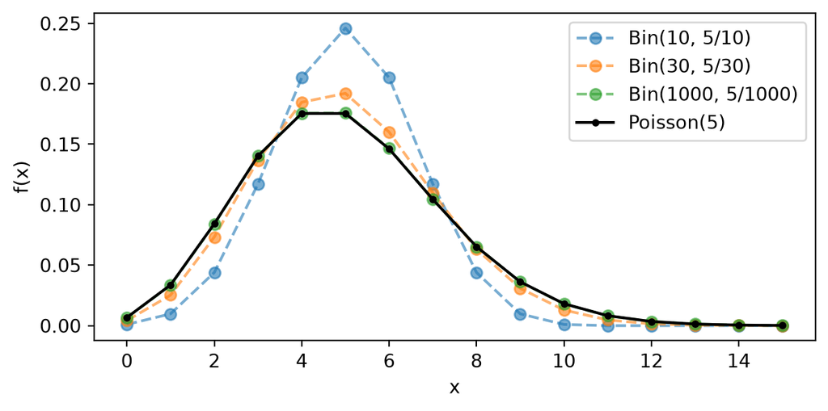

```python
λ, x = 5, np.arange(16)

fig, ax = plt.subplots(figsize=(7, 3.2))
for n in (10, 30, 1000):
    ax.plot(x, stats.binom(n, λ / n).pmf(x), 'o--', alpha=0.6,
            label=f'Bin({n}, {λ}/{n})')
ax.plot(x, stats.poisson(λ).pmf(x), 'k.-', label='Poisson(5)')
ax.set(xlabel='x', ylabel='f(x)')
ax.legend()
plt.show()
```

## Negative binomial

**Negative binomial distribution**

If $X$ is the number of failures before the $r$-th success, where $r$ is a positive integer and $0 < p \leq 1$, then
$$\Pr[X = x] = \binom{x + r - 1}{x} p^r (1-p)^x, \qquad x \in \{0, 1, 2, \ldots\}.$$

- Story: keep running trials until the $r$-th success; count the failures
- $r = 1$ recovers the geometric (but counting failures)

## The discrete family tree

| Name | PMF | Support | Story |
| --- | --- | --- | --- |
| Bernoulli | $p^x(1-p)^{1-x}$ | $\{0,1\}$ | One binary trial |
| Geometric | $p(1-p)^{x-1}$ | $1,2,\ldots$ | Trials until first success |
| Binomial | $\binom{n}{x}p^x(1-p)^{n-x}$ | $0,\ldots,n$ | Successes in $n$ trials |
| Neg. binomial | $\binom{x+r-1}{x}p^r(1-p)^x$ | $0,1,\ldots$ | Failures before $r$-th success |
| Poisson | $e^{-\lambda}\lambda^x/x!$ | $0,1,\ldots$ | Rare-event counts |

- Every family is just a repackaging of Bernoulli trials

# Continuous and normal-derived distributions

## Exponential

**Exponential distribution**

If $X \sim \operatorname{Exponential}(\lambda)$, where $\lambda > 0$, then the PDF is
$$f_X(x; \lambda) = \lambda e^{-\lambda x}, \qquad x \in [0, \infty).$$

- Continuous analogue of the geometric: time until the next event, rather than trials until the first success
- Validity: $\int_0^\infty \lambda e^{-\lambda x} dx = \left. -e^{-\lambda x} \right|_0^\infty = 1$

## Explore the exponential PDF and CDF

$$f_X(x; \lambda) = \lambda e^{-\lambda x}, \qquad x \in [0, \infty).$$

## Exponential waiting times, simulated

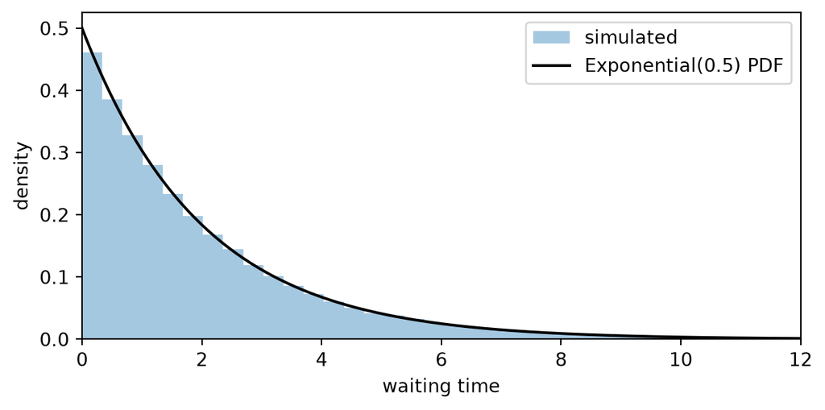

```python
waits = rng.exponential(scale=1/0.5, size=100_000)   # lambda = 0.5

x = np.linspace(0, 12, 200)
fig, ax = plt.subplots(figsize=(7, 3.2))
ax.hist(waits, bins=60, density=True, alpha=0.4, label='simulated')
ax.plot(x, stats.expon(scale=2).pdf(x), 'k', label='Exponential(0.5) PDF')
ax.set(xlabel='waiting time', ylabel='density')
ax.set(xlim=(0, 12))
ax.legend()
plt.show()
```

## Another binomial limit

As $n \to \infty$, what does the distribution of $X_n$ look like?

- Earlier: $p$ shrinking with $n$ ($np$ fixed) gave the Poisson
- Now we fix $p$ — different limit, different destination

## Binomial → Normal

## Normal

**Normal distribution**

If $X \sim \mathcal{N}(\mu, \sigma^2)$, where $\sigma^2 > 0$, then the PDF is
$$f_X(x; \mu, \sigma^2) = \frac{1}{\sqrt{2\pi\sigma^2}} \exp\left(-\frac{(x-\mu)^2}{2\sigma^2}\right),
\qquad x \in \mathbb{R}.$$

- $\mu = 0$, $\sigma^2 = 1$: the **standard normal**
- Standard notation: $\phi(x; \mu, \sigma^2)$ for the PDF and $\Phi(x; \mu, \sigma^2)$ for the CDF
- Arises when an outcome is the sum of many small, roughly independent effects

## Quantiles

**Quantile**

For $c \in (0, 1)$, the $c$th **quantile** of $X$ is
$$Q_X(c) = \min\{x \in \mathbb{R} : F_X(x) \geq c\}.$$
If $F_X$ is continuous and strictly increasing, $Q_X(c) = F_X^{-1}(c)$.

- The CDF maps a value to a probability; the quantile maps a probability back to a value
- The $c$th quantile is the $100c$th **percentile**; $Q_X(0.5)$ is the median

## Standard normal quantiles

Write $z_c$ for the $c$th quantile of $\mathcal{N}(0, 1)$, so $\Phi(z_c) = c$.

| $c$ | 0.90 | 0.95 | 0.975 | 0.995 |
| --- | --- | --- | --- | --- |
| $z_c$ | 1.282 | 1.645 | 1.960 | 2.576 |

- Symmetry: $z_{1-c} = -z_c$, so $z_{0.025} = -1.96$

## Explore normal percentiles

## A return quantile

**Example — Monthly return**

Suppose a portfolio’s monthly return is $X \sim \mathcal{N}(0.01, 0.05^2)$. Since $\Pr[X \leq \mu + \sigma z_c] = \Pr[Z \leq z_c] = c$,
$$Q_X(0.05) = 0.01 + 0.05 \, z_{0.05} = 0.01 - 0.05 \times 1.645 \approx -0.072.$$

- A 5% chance of losing more than 7.2% in a month: the 5% *value at risk*

## Quantiles, computed

```python
mu, sigma = 0.01, 0.05

# ppf ('percent point function') is SciPy's name for the quantile function
ppf = stats.norm.ppf(0.05, loc=mu, scale=sigma)

# The sample quantile of simulated returns
returns = rng.normal(mu, sigma, size=100_000)
quantile_5 = np.quantile(returns, 0.05)

print(f'Analytic 5th percentile:  {ppf:.4f}')
print(f'Simulated 5th percentile: {quantile_5:.4f}')
```

```
Analytic 5th percentile:  -0.0722
Simulated 5th percentile: -0.0719
```

## The De Moivre–Laplace theorem

**De Moivre–Laplace theorem**

Let $X_n \sim \operatorname{Bin}(n, p)$ with $q = 1 - p$. Then
$$\Pr[X_n = k] \approx \frac{1}{\sqrt{npq}}\,
\phi\!\left(\frac{k - np}{\sqrt{npq}}; 0, 1\right),
\qquad\text{and}\qquad
\frac{X_n - np}{\sqrt{npq}} \Rightarrow \mathcal{N}(0, 1).$$

- The normal is not an assumption — it is *derived* as the large-$n$ limit of coin flipping
- De Moivre (1733) for $p = \frac{1}{2}$; Laplace generalized
- This is the ancestor of the Central Limit Theorem

## Sketch of the derivation (I)

**Step 1 — look near the mean.** With $\mu = np$, $\sigma^2 = npq$, write $k = np + z\sqrt{npq}$ for fixed $z$.

**Step 2 — Stirling’s approximation.** For large $m$,
$$m! \sim \sqrt{2\pi m}\left(\frac{m}{e}\right)^m.$$

Applied to $\binom{n}{k}$, this yields
$$\Pr[X_n = k] \sim \frac{1}{\sqrt{2\pi}} \sqrt{\frac{n}{k(n-k)}}
\frac{n^n p^k q^{n-k}}{k^k (n-k)^{n-k}}.$$

- Everything else is just bookkeeping using logs and Taylor expansions

## Sketch of the derivation (II)

**Step 3 — take logs.** With $d = z\sqrt{npq}$, so $k = np + d$ and $n - k = nq - d$, expand $\log(1 \pm u) = \pm u - \frac{u^2}{2} + o(u^2)$ to find

$$\log\left(\frac{n^n p^k q^{n-k}}{k^k (n-k)^{n-k}}\right)
= -\frac{z^2}{2} + o(1).$$

**Step 4 — the constant.** Since $k \sim np$ and $n - k \sim nq$, $\sqrt{\frac{n}{k(n-k)}} \sim \frac{1}{\sqrt{npq}}$.

**Step 5 — recognize the density.**
$$\Pr[X_n = k] \sim \frac{1}{\sqrt{2\pi npq}}\, e^{-z^2/2}
= \frac{1}{\sqrt{npq}}\,\phi(z; 0, 1). \qquad \blacksquare$$

- The $e^{-z^2/2}$ comes from the quadratic term of a Taylor expansion — that’s “why” the normal has its shape

## The limit

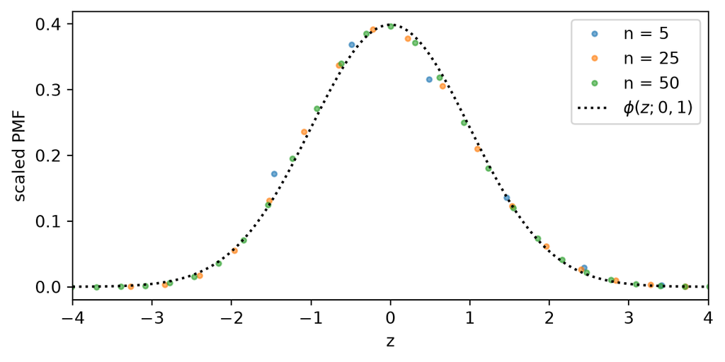

```python
p = 0.3
z = np.linspace(-4, 4, 400)

fig, ax = plt.subplots(figsize=(7, 3.2))
for n in (5, 25, 50):
    k = np.arange(n + 1)
    zk = (k - n * p) / np.sqrt(n * p * (1 - p))
    ax.plot(zk, stats.binom(n, p).pmf(k) * np.sqrt(n * p * (1 - p)),
            'o', ms=3, alpha=0.6, label=f'n = {n}')
ax.plot(z, stats.norm().pdf(z), 'k:', label=r'$\phi(z; 0, 1)$')
ax.set(xlim=(-4, 4), xlabel='z', ylabel='scaled PMF')
ax.legend()
plt.show()
```

## Other distributions derived from the normal

- Many important distributions are derived from the normal distribution
- The most important are the $\chi^2$, $t$, and $F$ distributions, which are the reference distributions for *hypothesis testing*
- Some others include the log-normal, and the Gamma and Beta distributions, which are frequently used in Bayesian statistics

## The $\chi^2$ distribution

**$\chi^2$ distribution**

Let $Z_1, Z_2, \ldots, Z_\nu$ be independent standard normal random variables. Then
$$X = \sum_{i=1}^{\nu} Z_i^2 \sim \chi^2_\nu$$
(chi-square with $\nu$ degrees of freedom), supported on $[0, \infty)$.

Try to visualize the shape of this distribution. How would the shape change as $\nu$ increases?

## The $\chi^2$ PDF and CDF

$$f_{\chi^2}(x; \nu) =
\frac{1}{2^{\nu/2}\Gamma\!\left(\frac{\nu}{2}\right)}
x^{\nu/2 - 1} e^{-x/2},
\qquad x > 0.$$

## Aside: The gamma function

$$\Gamma(x) = \int_0^\infty s^{x-1} e^{-s} ds, \qquad x \in \mathbb{C}, \Re(x) > 0.$$

It can be shown that for any positive integer $n$,
$$\Gamma(n) = (n-1)\Gamma(n-1) = (n-1)!$$
Therefore, the gamma function extends the factorial function to real (and complex) numbers.

## The gamma function

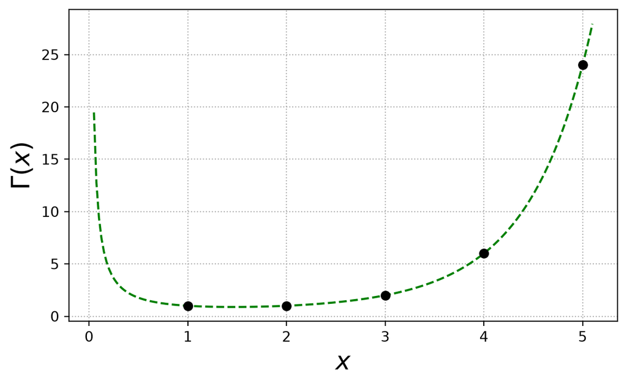

```python
from scipy.special import gamma, factorial

plt.figure(figsize=(7,4))
x = np.linspace(0.05,5.1,200)
plt.plot(x, gamma(x), 'g--')
n = np.arange(6)
plt.plot(n, gamma(n), 'ko')
plt.xlabel('$x$', fontsize=18)
plt.ylabel(r'$\Gamma(x)$', fontsize=18)
plt.grid(ls=':')
plt.show()
```

## Constructions, verified

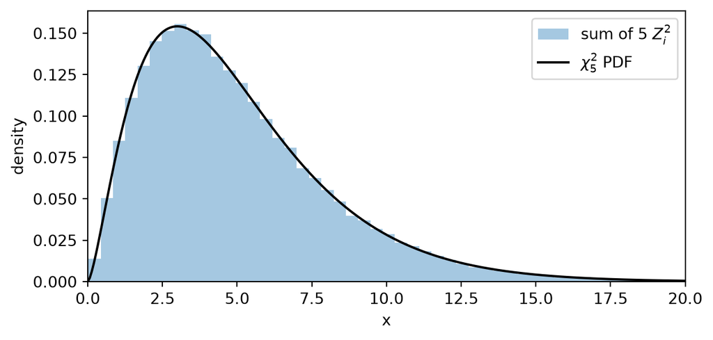

```python
Z = rng.standard_normal((100_000, 5))
chi2_sim = (Z ** 2).sum(axis=1)                  # chi-square, 5 df

x = np.linspace(0, 20, 300)
fig, ax = plt.subplots(figsize=(7, 3.2))
ax.hist(chi2_sim, bins=80, density=True, alpha=0.4, label='sum of 5 $Z_i^2$')
ax.plot(x, stats.chi2(5).pdf(x), 'k', label=r'$\chi^2_5$ PDF')
ax.set(xlabel='x', ylabel='density')
ax.set_xlim(0, 20)
ax.legend()
plt.show()
```

## Built from the normal: $t$ and $F$

**Student’s $t$ distribution**

Let $Z \sim \mathcal{N}(0,1)$ and $U \sim \chi^2_\nu$, independent. Then
$$T = \frac{Z}{\sqrt{U / \nu}} \sim t_\nu.$$

**$F$ distribution**

Let $U_1 \sim \chi^2_{d_1}$ and $U_2 \sim \chi^2_{d_2}$, independent. Then
$$F = \frac{U_1 / d_1}{U_2 / d_2} \sim F_{d_1, d_2}.$$

- $t$: a normal divided by an *estimate* of its scale — heavier tails; $t_\nu \to \mathcal{N}(0,1)$ as $\nu \to \infty$
- $F$: a ratio comparing two variances

## Explore the Student’s $t$ PDF and CDF

$$f_t(x; \nu) =
\frac{\Gamma\!\left(\frac{\nu + 1}{2}\right)}
{\sqrt{\nu\pi}\,\Gamma\!\left(\frac{\nu}{2}\right)}
\left(1 + \frac{x^2}{\nu}\right)^{-\frac{\nu + 1}{2}},
\qquad x \in \mathbb{R}.$$

## Explore the $F$ PDF and CDF

$$f_F(x; d_1, d_2) =
\frac{\Gamma\!\left(\frac{d_1 + d_2}{2}\right)}
{\Gamma\!\left(\frac{d_1}{2}\right)\Gamma\!\left(\frac{d_2}{2}\right)}
\left(\frac{d_1}{d_2}\right)^{d_1/2}
x^{d_1/2 - 1}
\left(1 + \frac{d_1}{d_2}x\right)^{-\frac{d_1 + d_2}{2}},
\qquad x > 0.$$

## Log-normal

**Log-normal distribution**

Let $Y \sim \mathcal{N}(\mu, \sigma^2)$ and define $X = \exp(Y)$. Then $X$ is log-normal: positive, right-skewed, and $\log X$ is normal.

- The workhorse for positive, skewed quantities: prices, firm sizes, durations
- Multiplicative version of the normal’s additive story: products of many small factors

## Explore the log-normal PDF and CDF

$$f_X(x; \mu, \sigma) =
\frac{1}{x\sigma\sqrt{2\pi}}
\exp\!\left(-\frac{(\log x - \mu)^2}{2\sigma^2}\right),
\qquad x > 0.$$

## Percentiles

## Continuous and normal-derived distributions recap

- Exponential: continuous waiting times, the geometric’s analogue
- The normal is *derived*: standardized binomial → $\phi(z; 0, 1)$ via Stirling (De Moivre–Laplace) — the CLT’s ancestor
- $\chi^2$ (sum of squared normals), $t$ (normal over estimated scale), $F$ (variance ratio): the reference distributions of hypothesis testing
- Next session: random samples, sampling distributions, and inference